# Introducing the M&E Bullet chart

This post is for the **Monitoring and Evaluation (M&E)** people out there (or MEL,MERL, or whatever else the cool kids are calling themselves these days). For the purposes of this report, we will focus on M&E deliverables, which are called **“Indicators”**, but this post will also come in handy for anyone that depends on Key Performance Indicators (KPI)s or those that need to track progress against a target. **TL;WR** version, we recommend a hacked version of the bullet-chart… and provide the R-code to accomplish the same on our [github page](https://github.com/ACDIVOCATech/AV.BulletChart). This post was co-written by our Data Analytics and Viz Intern, [Ryo Nakagawara](https://www.ryo-n7.github.io/aboutme).

For those of you completely unfamiliar, at **ACDI/VOCA** we have projects that we implement around the world, and in order to ensure that we are implementing them correctly, we have indicators that have yearly targets, and we must continuously track progress against these yearly indicators in order to ensure we are implementing the project correctly and having an impact.

Now, the **first problem** one might have is they don’t have real-time data to monitor. If you dont’t have a real-time data system, then go back and work on that and come back in a year or two :). Since ACDI/VOCA does have a near real-time data management system, we can proceed.

The **second problem** is that not all indicators “receive data” throughout the year… there is a very detailed schedule that governs what gets collected when, but long story short, a good amount of data comes in at the end of the year. M&E folk have several classifications for indicators, but since we are data people, we divide this up into two groups: **Routine** (or Ongoing) **Indicators**, and **Yearly Indicators**. By throwing away the yearly indicators, we are left with an indicator set that we can expect should be updated frequently… and thus we can use these to figure out if we’re falling behind. Not to say that the yearly data isn’t important, that’s **THE MOST** important… but it measures impact (more or less), not implementation and can’t be used for quick corrections.

The **third problem** is that measuring progress against a end-of-year target would mean that for the majority of the year, the % accomplishment will be low-ish (because the year isn’t over yet and we’re still doing stuff!). A naive trick that can be employed is to expect that indicator accomplishment be *more or less linear*. If we assume this, then we if we divide the indicator accomplishment by the % of year elapsed, we can expect all indicators to be at 100% of where we should be (For example, when we are 25% through the `year` (whether it be calendar year or fiscal year) we can assume we should be 25% through the target… 25/25 = 100%). Clear as mud?

Now, this is a *problematic* assumption, especially in agricultural development projects, where activities are absoultely **not** linear, and by design. For example, some indicators might require distribution of money or inputs, something that should be done early in the year, and some activities might happen later in the year, perhaps right before seeding, harvest, or sales. These curves might look like this:

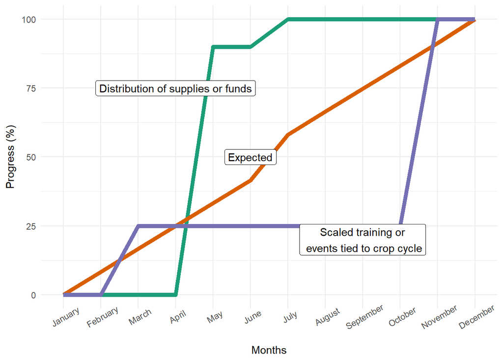

One way to deal with this is to assign projections and track each indicator against the projection… but this approach is not without its problems. We will revisit these non-linearities later, but for the moment, let’s ignore them and assume that indicator progression is linear. So what is the best way to track these indicators? Let’s introduce the bullet chart!

## Bullet chart

The **bullet chart** was invented by [Stephen Few](https://www.perceptualedge.com/articles/misc/Bullet_Graph_Design_Spec.pdf), for the purpose of showing tons of info in a condensed form in KPIs.

This type of graph is a variation on a typical bar graph with a thick line presenting an important point for that indicator (benchmark, performance target, etc.) and other bars in the background that can signify different levels of performance (low-high, bad-good, etc.). This type of graph makes it very easy to compare between related measures (e.g. present status versus status at similar time in the past) such as necessary in our case.

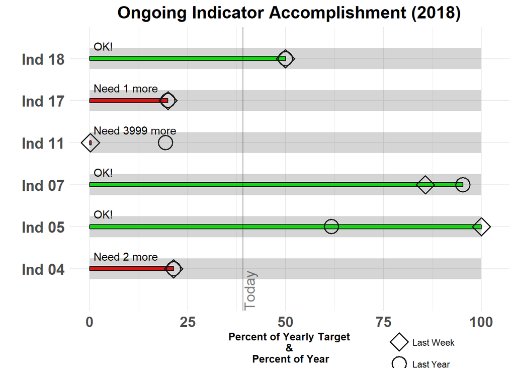

OK, there’s tons going on here, so let’s explain! As you can see, the bars show the progression along the horizontal-axis presenting the percentage of the yearly target completed. Also, along this axis is the percent of the year gone by with a vertical line indicating what exact percentage **“Today”** is along this percentage. It is necessary to use percentages as we have multiple indicators of varying units/parameters for each project!

Each bar is colored green if it’s close to or past **“Today”**, orange if it’s close, and red if it’s not. Instead of showing a vertical tick mark on each bar, we show a constant **“Today”** line that progresses from 0-100% of the year. However, if individual targets based on projections are desired, one could easily show these as individual lines instead of today line, see below.

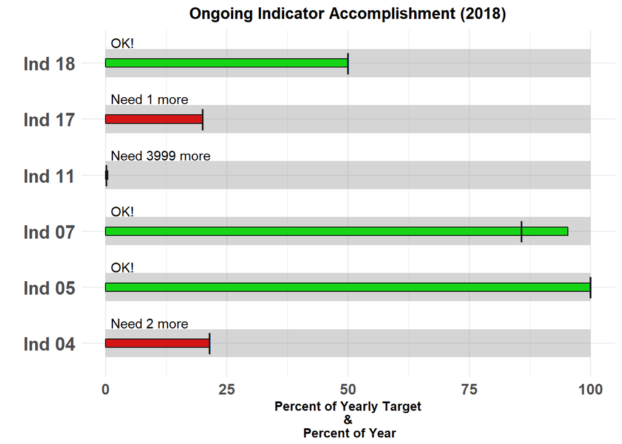

Returning to the original graph, there are two symbols displayed in addition to the bars, a circle and a diamond. The diamond shows where we were last week (or two weeks… some configurable short-term indicator, and the circle shows where we were last year, today. These benchmarks serve to show whether there is ongoing progress for the diamond, and the progress compared to last year is important in that it compares year-to-year performance. We have found that this is enough to provide an indication to managers about whether an indicator is behind or ahead, even if we are “behind” compared to **“Today”**.

The above mentioned symbols are being used instead of the additional bars in a traditional bullet graph, because we thought it was clearer to understand, but here is a version that uses differently sized bars to compare last-week and last-year instead.

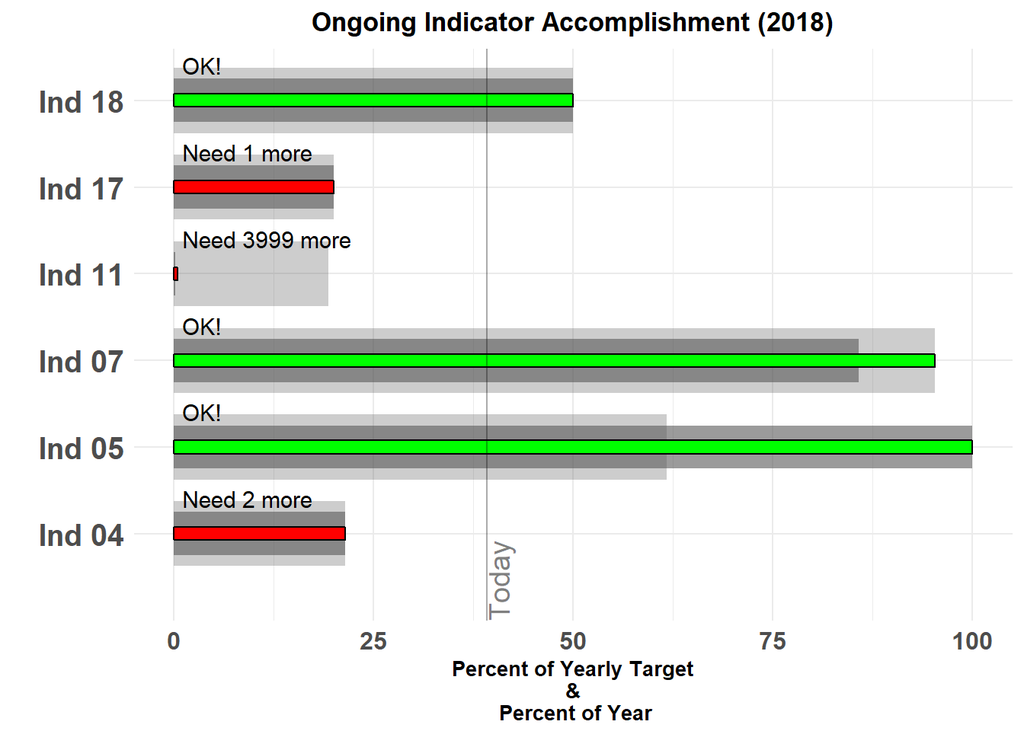

In this one, we conform more closely to the standard bulletchart design. The main difference however, is to use different thickness as the benchmarks for previous time points to further accentuate the difference graphically.

We have heard great things about this bullet chart from the field in that it allows our viewers/stakeholders to take one quick look to see what needs work. We hope that this is useful to you also! In case you would like to [download a version, or collaborate](https://github.com/ACDIVOCATech/AV.BulletChart), we invite **Pull Requests**!